# Winter wheat

Dr. Emily Burchfield

## Bright spots analysis

### Full panel overview

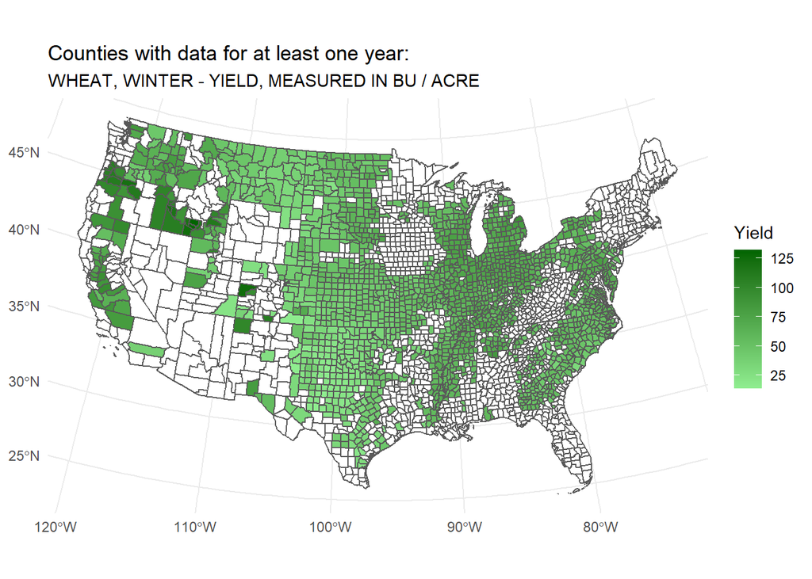

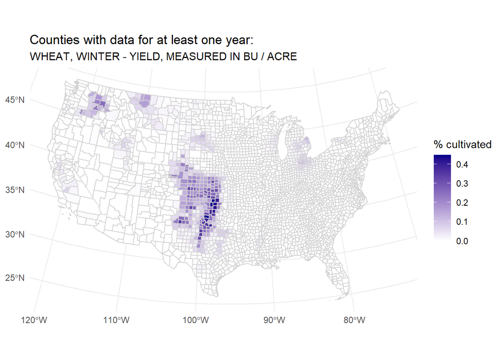

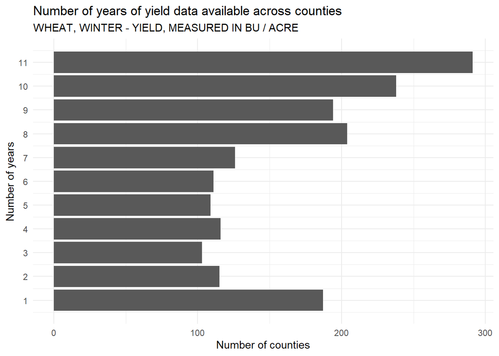

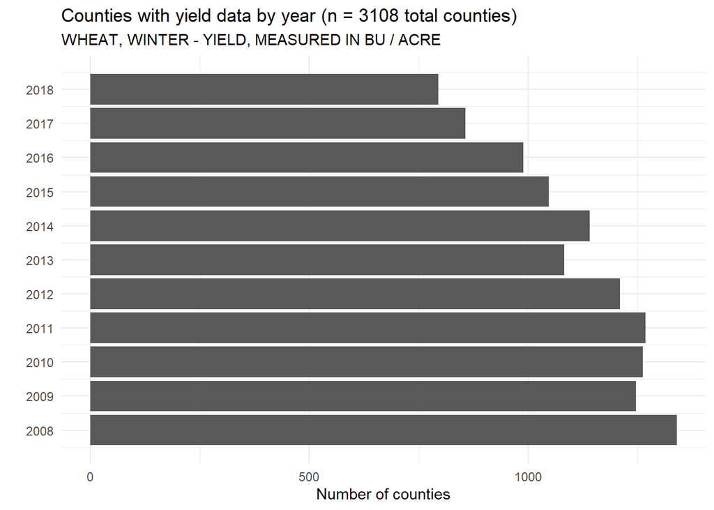

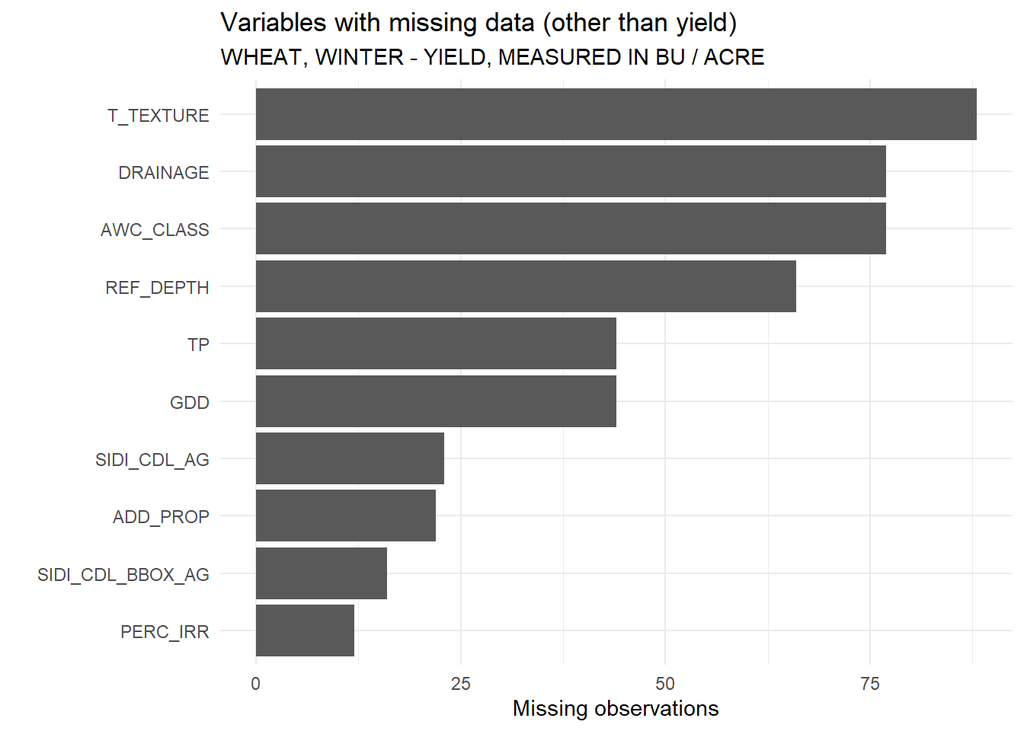

Notes on missing data:

- PRISM data is missing for the following counties due to a data corruption issue in the original PRISM data: `51600, 51610, 51678, 51685`
- `SIDI_CDL*_AG` columns are missing data in a few counties; likely due to the mask.

### Final panel overview

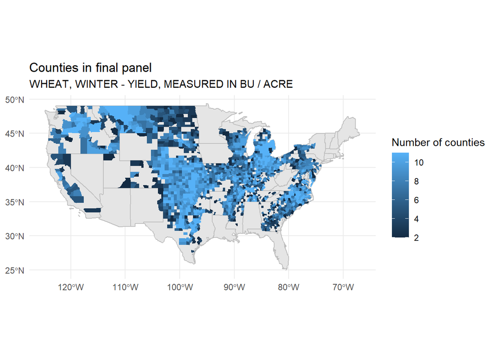

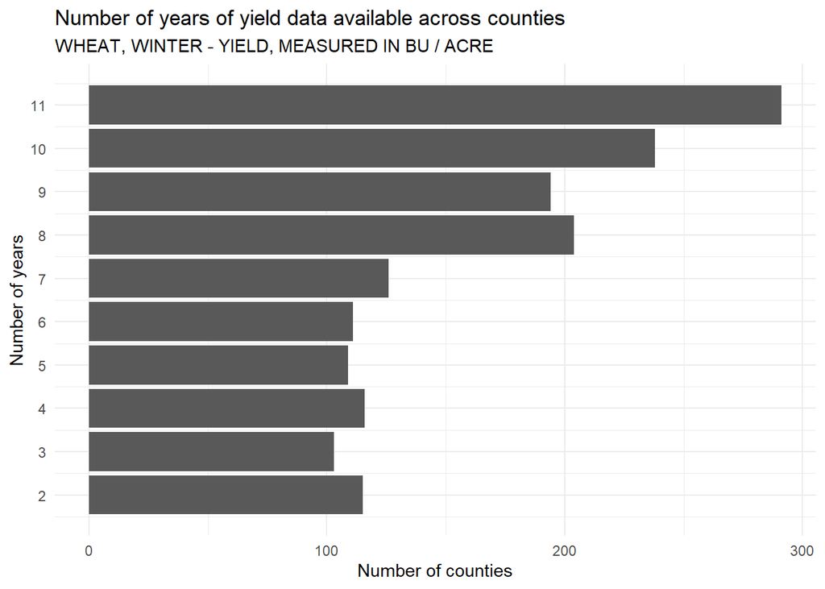

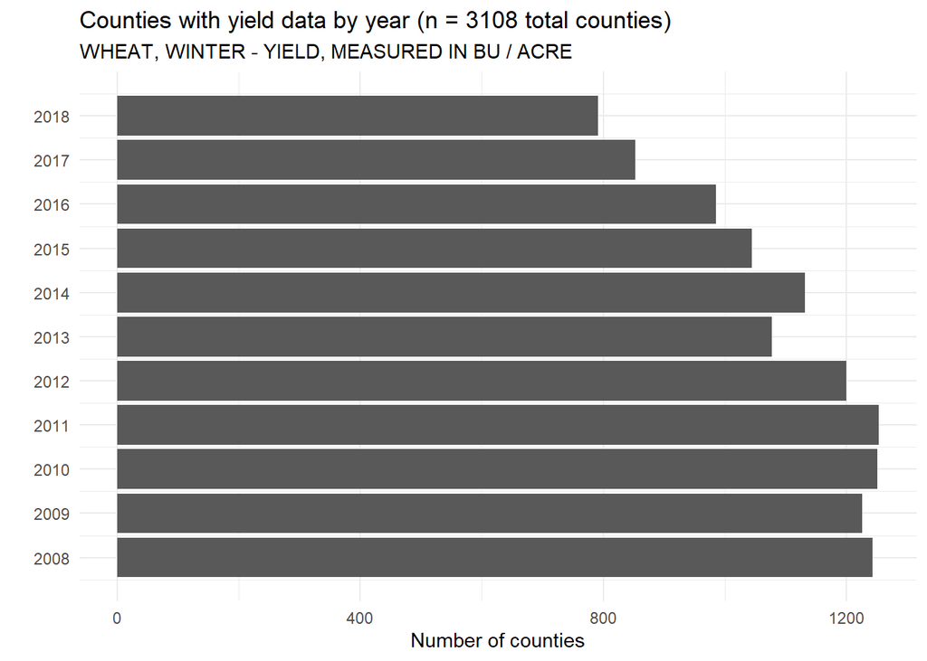

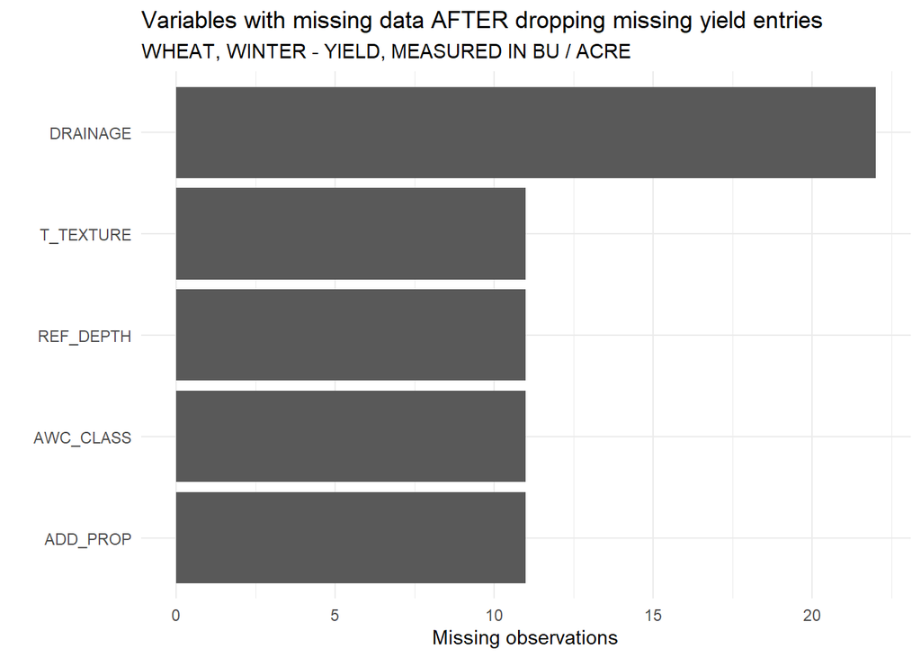

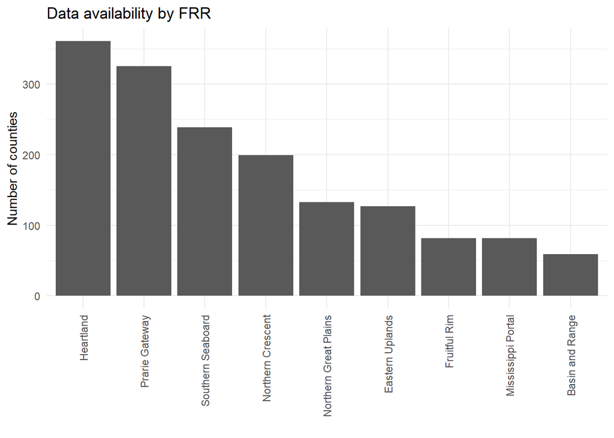

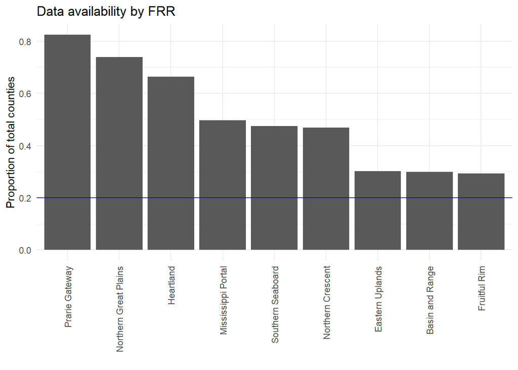

```
## [1] "Excluded FRRs are: "
```

```
## factor(0)
## 9 Levels: Basin and Range Eastern Uplands Fruitful Rim Heartland Mississippi Portal Northern Crescent ... Southern Seaboard
```

| FRR_ID | FRR_NAME | COUNTY_AV | COUNTY_TOTAL | PERC_AV |
| --- | --- | --- | --- | --- |
| 1 | Heartland | 361 | 544 | 0.6636029 |
| 2 | Northern Crescent | 199 | 424 | 0.4693396 |
| 3 | Northern Great Plains | 133 | 180 | 0.7388889 |
| 4 | Prarie Gateway | 325 | 394 | 0.8248731 |
| 5 | Eastern Uplands | 127 | 421 | 0.3016627 |
| 6 | Southern Seaboard | 239 | 503 | 0.4751491 |
| 7 | Fruitful Rim | 82 | 280 | 0.2928571 |
| 8 | Basin and Range | 59 | 197 | 0.2994924 |
| 9 | Mississippi Portal | 82 | 165 | 0.4969697 |

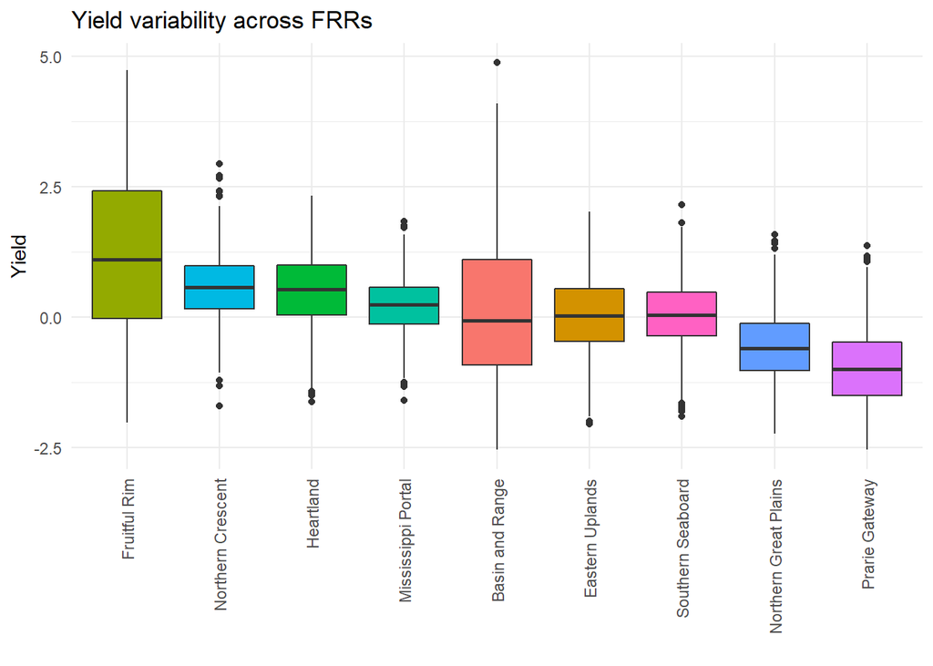

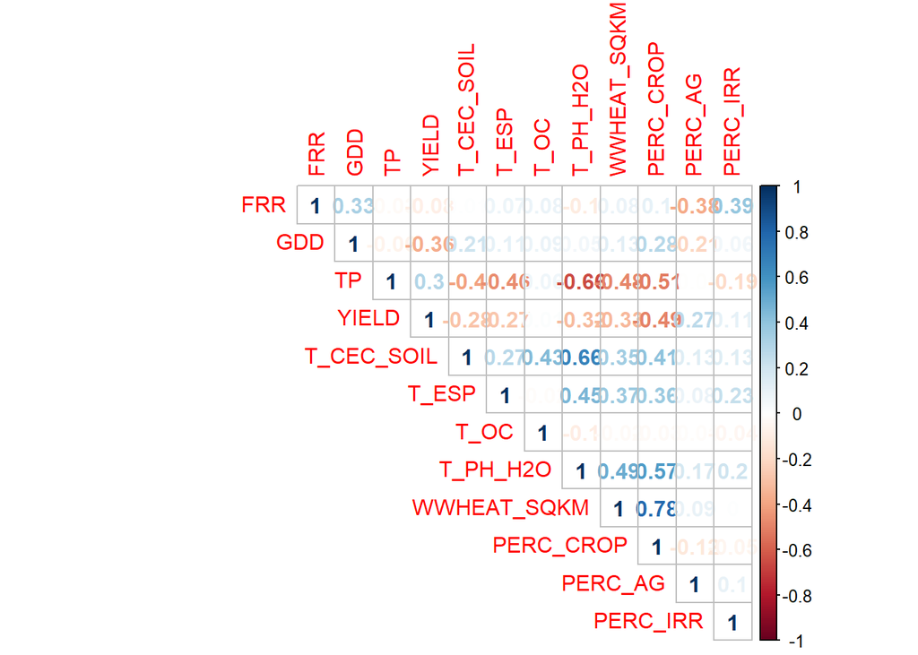

Here are the variables that still have a correlation above `0.5` (or below `-0.5`):

Variable pairs with high correlation

| Var1 | Var2 | Freq |
| --- | --- | --- |
| PERC_CROP | WWHEAT_SQKM | 0.78 |
| WWHEAT_SQKM | PERC_CROP | 0.78 |
| T_PH_H2O | TP | -0.66 |
| T_PH_H2O | T_CEC_SOIL | 0.66 |
| TP | T_PH_H2O | -0.66 |
| T_CEC_SOIL | T_PH_H2O | 0.66 |
| PERC_CROP | T_PH_H2O | 0.57 |
| T_PH_H2O | PERC_CROP | 0.57 |
| PERC_CROP | TP | -0.51 |
| TP | PERC_CROP | -0.51 |

And for reference, here is the adjacency structure used in the models:

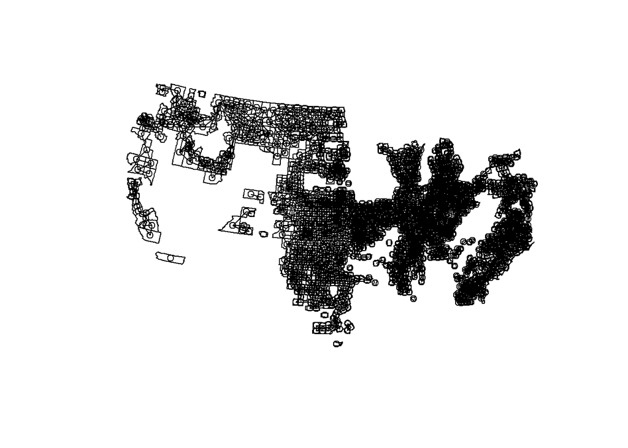

### Model specification

```r
  out <- prep_data(crop)
  null <- out[[1]]
  county_sub <- out[[2]]
  hadj <- build_adj_matrix(county_sub)

  null <- null %>% mutate_at(c("GDD", "TP"), ~inla.group(., n = 20, method = "quantile"))
  u <- sd(null$YIELD, na.rm = T)

  apar <- 0.5
  lmod <- lm(YIELD ~ GDD + TP  + T_CEC_SOIL + T_OC + T_PH_H2O + T_ESP +
               PERC_IRR +
               factor(YEAR), data=  null)
  bpar <- apar*var(residuals(lmod))
  lgprior <- list(prec = list(prior = "loggamma", param = c(apar, bpar)))

  formula <- YIELD ~ 1 +
    f(ID, model="bym2",
      graph=hadj,
      scale.model=TRUE,
      constr = TRUE) +
    f(FRR, model = "iid", hyper = lgprior) +
    f(GDD, model = "rw2",
      scale.model = T,
      hyper = list(theta = list(prior = "pc.prec",
                                param = c(u, 0.01)))) +
    f(TP, model = "rw2",
      scale.model = T,
      hyper = list(theta = list(prior = "pc.prec",
                                param = c(u, 0.01)))) +
    PERC_IRR +
    T_CEC_SOIL + T_OC + T_PH_H2O + T_ESP +
    factor(YEAR)

  mf <- inla(formula, data=null, family="gaussian",
             control.predictor = list(compute=T),
             control.compute = list(dic=T, cpo=T))
  df <- model_diagnostics(mf, null)
```

### Model results

Remember that variables have been *scaled* prior to running the analysis.

```
##
## Call:
##    c("inla(formula = formula, family = \"gaussian\", data = null, control.compute = list(dic = T, ", " cpo = T),
##    control.predictor = list(compute = T))")
## Time used:
##     Pre = 15.1, Running = 46.5, Post = 1.3, Total = 62.9
## Fixed effects:
##                    mean    sd 0.025quant 0.5quant 0.975quant   mode kld
## (Intercept)      -0.001 0.119     -0.236   -0.001      0.235 -0.001   0
## PERC_IRR          0.139 0.014      0.112    0.139      0.166  0.140   0
## T_CEC_SOIL       -0.037 0.025     -0.088   -0.037      0.013 -0.037   0
## T_OC              0.035 0.019     -0.002    0.035      0.072  0.035   0
## T_PH_H2O          0.070 0.031      0.010    0.070      0.130  0.070   0
## T_ESP             0.032 0.015      0.003    0.032      0.061  0.032   0
## factor(YEAR)2009 -0.302 0.018     -0.338   -0.302     -0.267 -0.302   0
## factor(YEAR)2010 -0.245 0.018     -0.281   -0.245     -0.209 -0.245   0
## factor(YEAR)2011 -0.106 0.018     -0.141   -0.106     -0.071 -0.106   0
## factor(YEAR)2012  0.025 0.021     -0.017    0.025      0.066  0.025   0
## factor(YEAR)2013  0.056 0.019      0.019    0.056      0.093  0.056   0
## factor(YEAR)2014 -0.018 0.019     -0.055   -0.018      0.019 -0.018   0
## factor(YEAR)2015 -0.109 0.019     -0.146   -0.109     -0.072 -0.109   0
## factor(YEAR)2016  0.342 0.021      0.300    0.342      0.383  0.342   0
## factor(YEAR)2017  0.237 0.023      0.192    0.237      0.282  0.237   0
## factor(YEAR)2018  0.070 0.021      0.029    0.070      0.111  0.070   0
##
## Random effects:
##   Name     Model
##     ID BYM2 model
##    FRR IID model
##    GDD RW2 model
##    TP RW2 model
##
## Model hyperparameters:
##                                           mean     sd 0.025quant 0.5quant 0.975quant   mode
## Precision for the Gaussian observations  5.331  0.079      5.189    5.325      5.500  5.305
## Precision for ID                         1.375  0.080      1.245    1.366      1.556  1.335
## Phi for ID                               0.967  0.031      0.882    0.977      0.991  0.986
## Precision for FRR                        7.280  3.703      1.907    6.723     15.948  5.083
## Precision for GDD                       32.130 24.182      7.737   25.459     95.755 16.889
## Precision for TP                        53.880 29.009     15.523   48.195    125.679 36.680
##
## Expected number of effective parameters(stdev): 1257.37(24.43)
## Number of equivalent replicates : 9.59
##
## Deviance Information Criterion (DIC) ...............: 15306.30
## Deviance Information Criterion (DIC, saturated) ....: 13267.52
## Effective number of parameters .....................: 1257.60
##
## Marginal log-Likelihood:  -8718.54
## CPO and PIT are computed
##
## Posterior marginals for the linear predictor and
##  the fitted values are computed
```

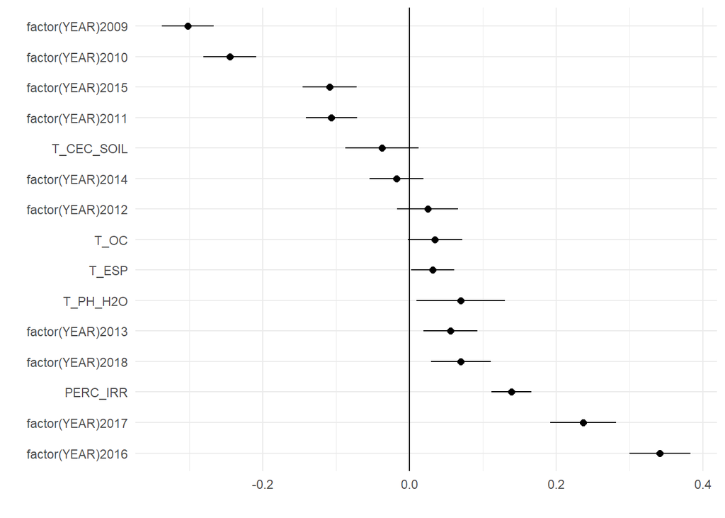

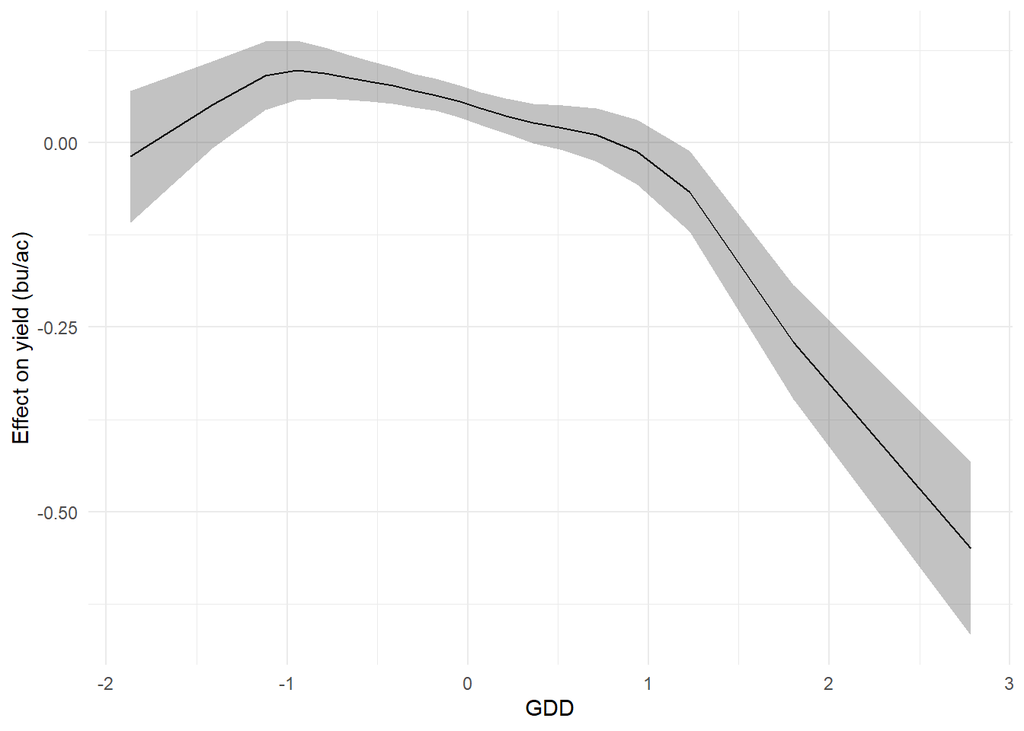

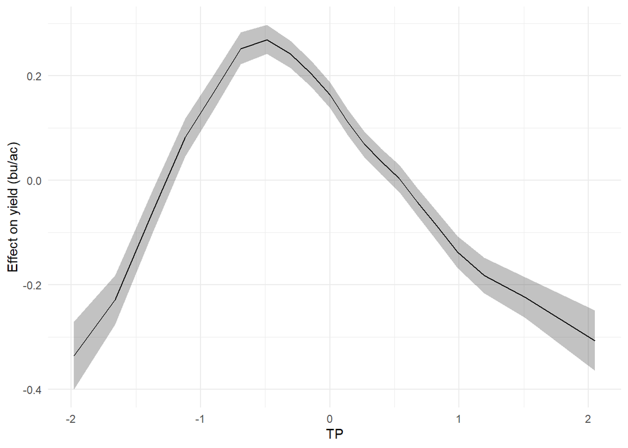

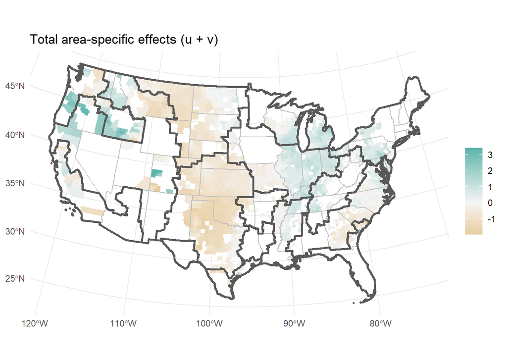

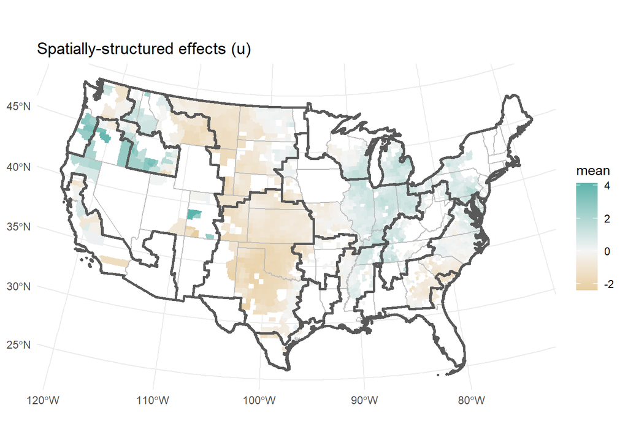

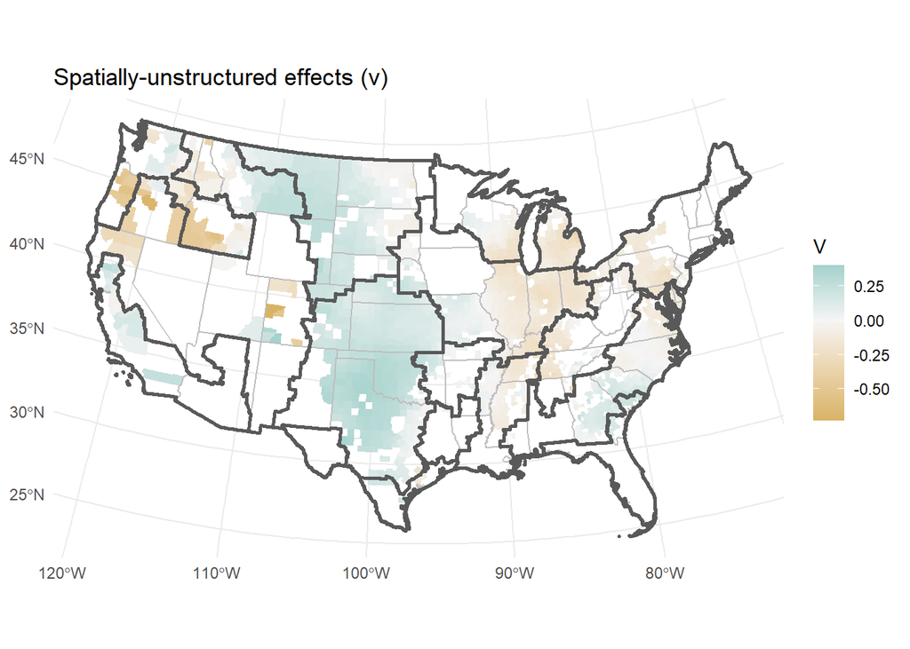

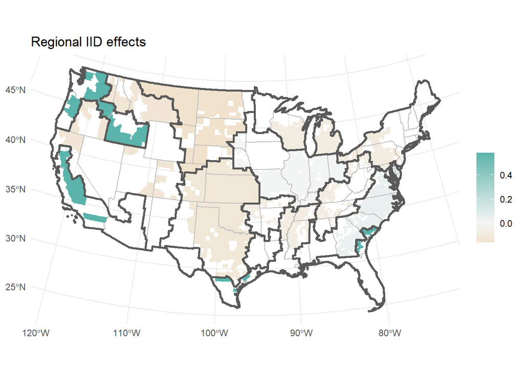

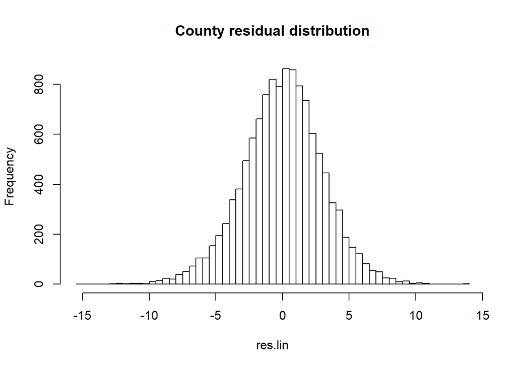

### Model diagnostics

How about general model diagnostics:

```r
modd$DIC
```

```
## [1] 15306.3
```

```r
modd$CPO
```

```
## [1] -7761.988
```

```r
modd$MSE
```

```
## [1] 0.1681143
```

```r
modd$R2
```

```
## [1] 0.7933171
```

The probability integral transform (PIT) is another leave-one-out-cross-validation check that evaluates the predictive performance of the model where a Uniform distribution of PIT means the predictive distribution matches well with the data.

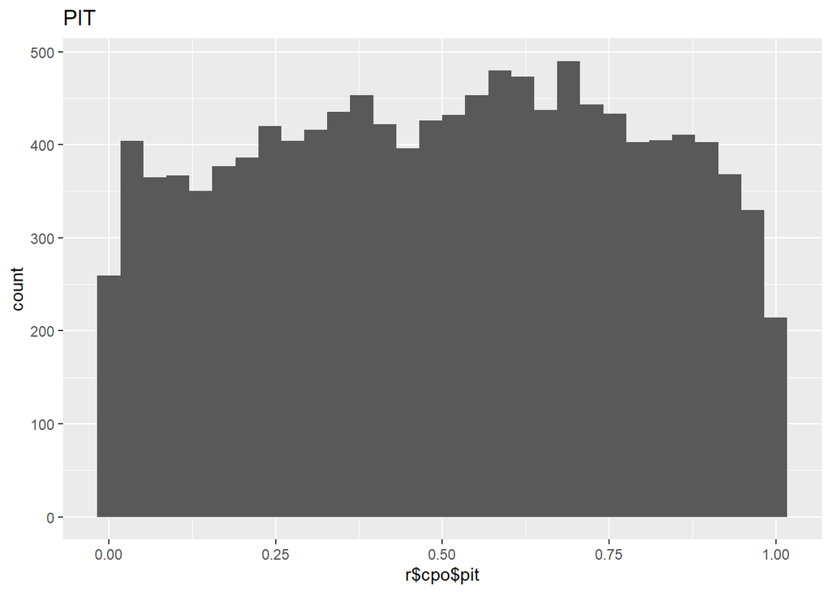

The second PPC provides a histogram of the posterior predictive p-value which estimates the probability of predicting a value more extreme than the observed value, where values near 0 and 1 indicate that the model does not adequately account for the tails of the observed distribution.

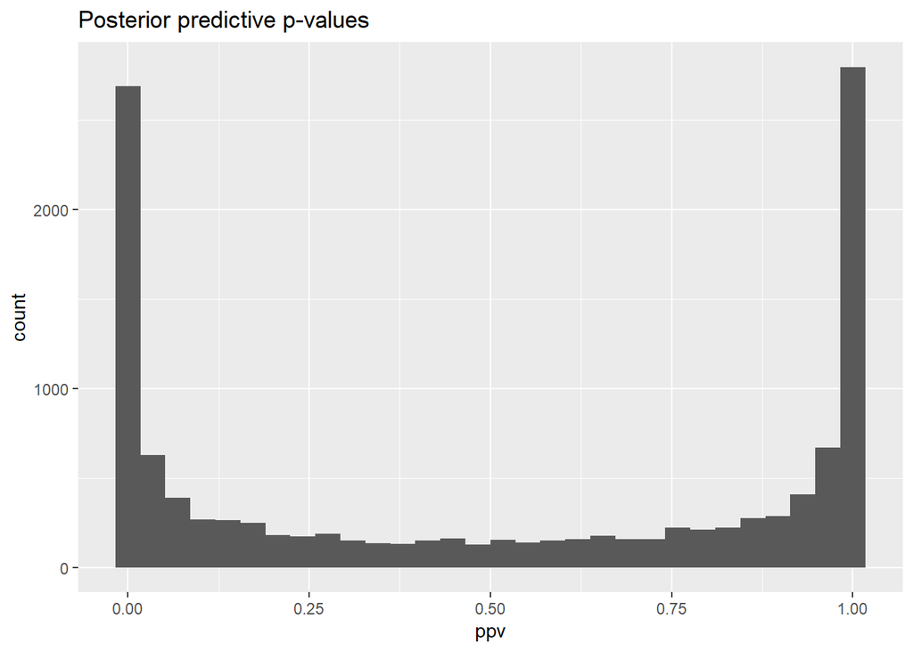

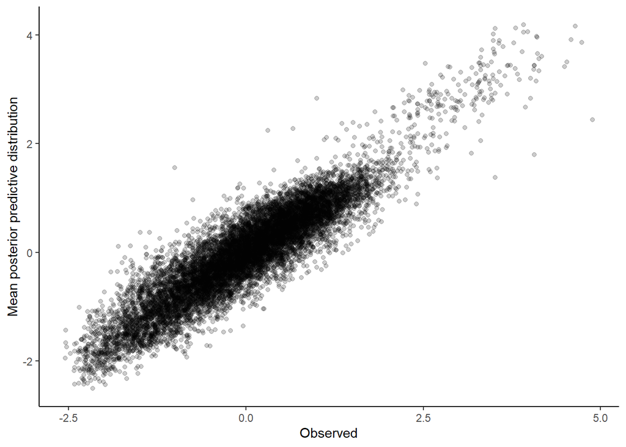

### FRR bright spots

#### First with “county effects” as u + v

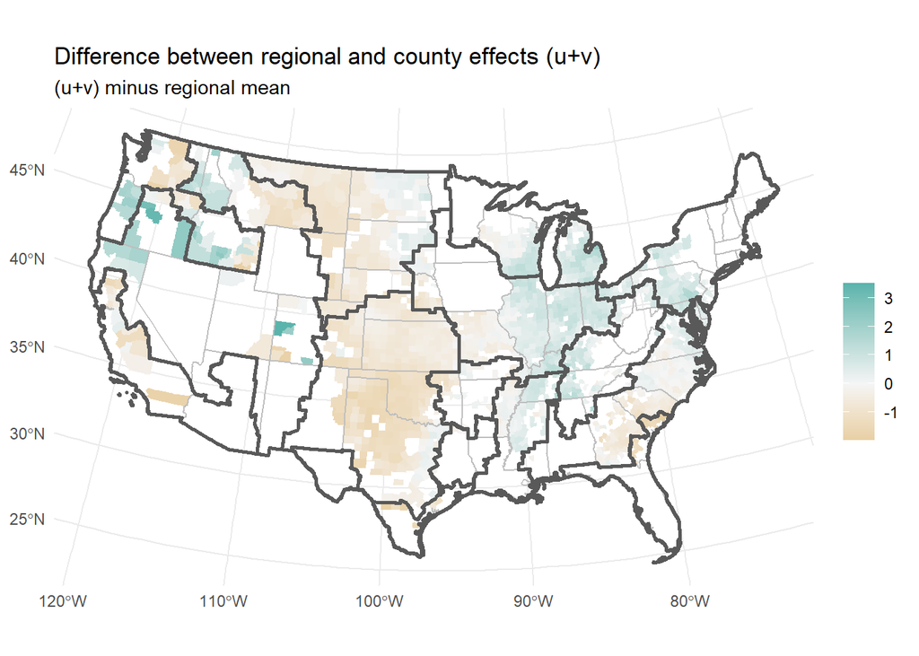

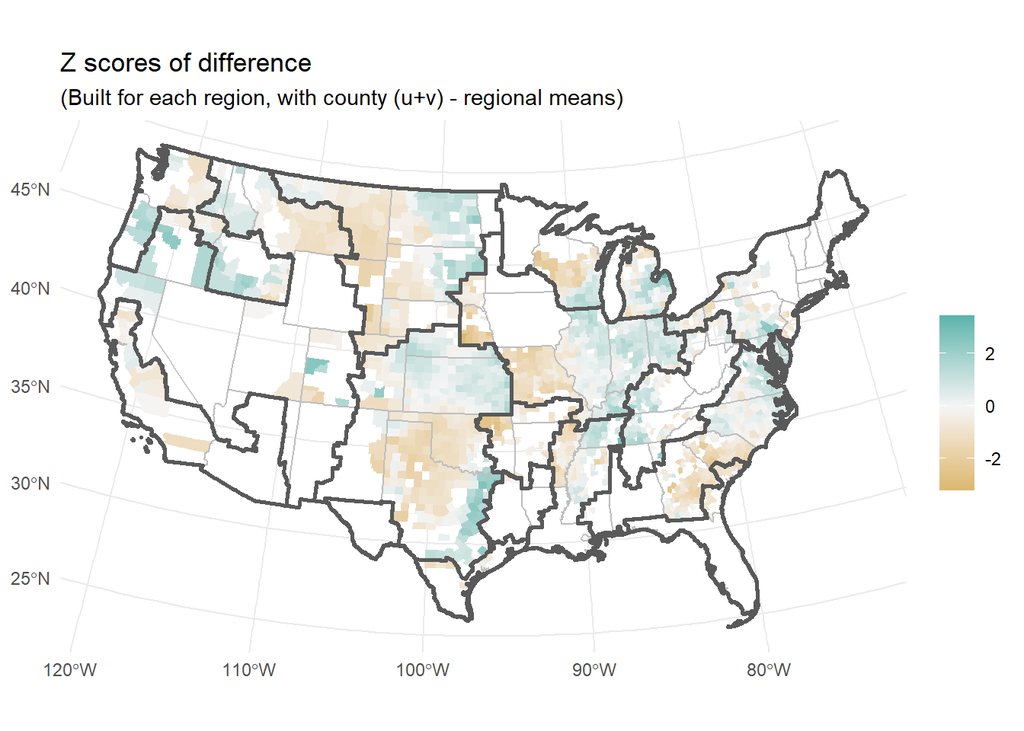

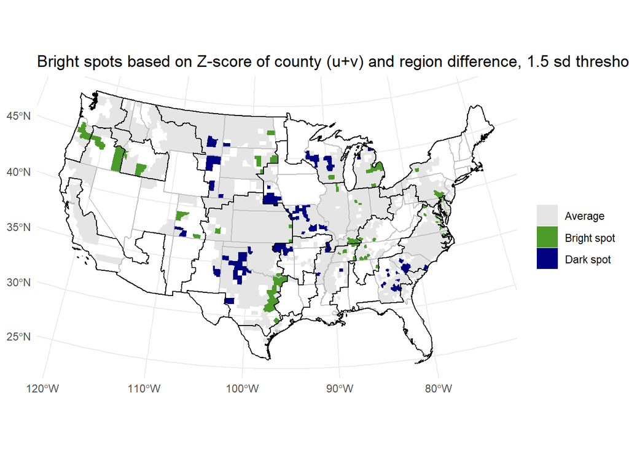

#### Now with “county effects” as v only

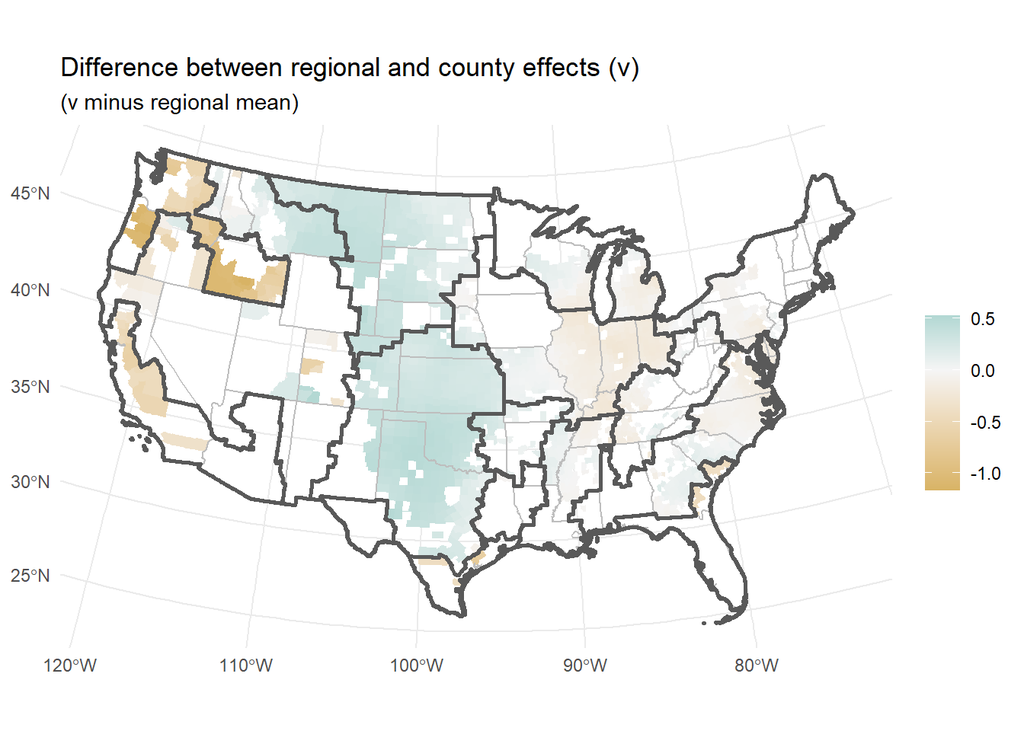

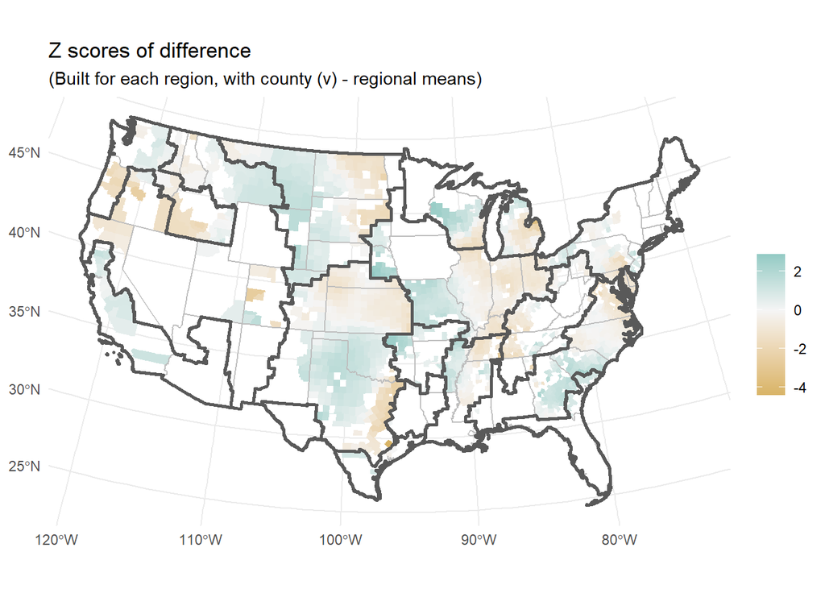

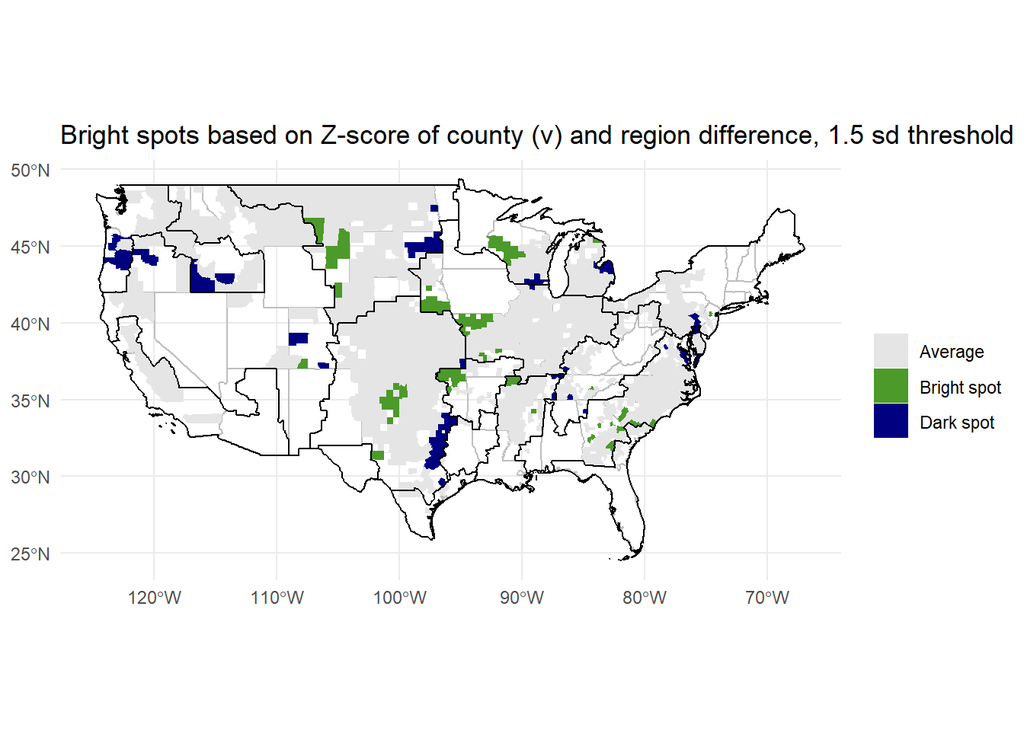